# Is democracy behind economic openess?

Alejandro Aísa

2023-03-26

## Libraries

```r
library(vdemdata)
library(tidyverse)
library(factoextra)
library(countrycode)
library(mice)
library(DataExplorer)
library(Hmisc)
library(corrplot)
library(caret)
library(glmnet)
library(GGally)
library(pROC)
library(MASS)
```

## The problem:

Ever since the fall of the Soviet Union, liberal democracy has expanded all over the world. Ideas like free elections, media freedom and division of power have taken over most of the political discourses and constitutions. Similarly, the expansion of free trade has reached almost all parts of the globe. Organizations like the WTO or the European Union were born to promote and protect the circulation of goods, capital and people over the world, or at least over substantial parts of it. These two ideas are at the core of the current globalization process. Therefore, politic and academic circles have wondered about the relationship between these two. Is democracy linked to the expansion of free trade? Numerous works and studies have been performed about it.

Building on this assumption, this work will try to explain and predict if democratic features are behind the relative size of trade within a country. More specifically, we will seek to forecast either if a country is a *low trader* one and the bulk of trade relative to its GDP (trade as a percentage of GDP).

## Feature Selection

### V-dem

Similarly to previous reports, we are going to resort to the database created and maintained by the Department of Political Science of the University of Gothenburg: Varieties of Democracy (V-Dem). As customary, we will download the variables as an R package from CRAN. After that, we will select only a representative sample of these variables. For future filtering and covariate controlling, we are also going to include some geographical and demographic features such as the area of the countries and their population.

The first filtering step that we may do refers to the time scope we are interested in. As we would like to focus only to the globalization era after the Cold War, we will select only the years within the XXI century; the first years after the fall of the Soviet Union were very turbulent from a political and economic point of view, then we are going to exclude them. Similarly, the COVID pandemic affected the global trade in, so we will need to skip them. Hence why the period 2000-2019 is the final time scope.

```r
df <- vdemdata::vdem

df_selected <- df %>% dplyr::select(year, country_name, v2x_libdem, country_text_id, v2xel_frefair, v2elsuffrage, v2psoppaut, v2ddthreci, v2ddthrerf, v2exbribe, v2lgoppart, v2dlengage, v2juhcind, v2juncind,  v2svstterr, v2csgender, v2mecenefm, v2peedueq, v2clgencl, v2clpolcl, v2caassemb, v2cafres, e_regionpol, e_wb_pop, e_area)

df_time  <- df_selected %>% filter(year > 1999 & year < 2020)
```

Next step for cleaning data involves the creation of an index variable accounting for the Country Code and the year, for identification purposes. In a similar line of reasoning, we are going to rename all of the variables to make them more comprehensive.

```r
df_renamed <- df_time %>%
  mutate(
  country_year = paste0(country_text_id, year)) %>%
transmute(
  year,
  country_name,
  CountryCode = country_text_id,
  country_year,
  lib_dem = v2x_libdem,
  clean_elections = v2xel_frefair,
  pcg_suffrage = v2elsuffrage,
  opp_parties = v2psoppaut,
  pop_initiative = v2ddthreci,
  pop_referendum = v2ddthrerf,
  exc_bribery = v2exbribe,
  opp_oversight = v2lgoppart,
  pop_deliberations = v2dlengage,
  jud_independence = v2juhcind,
  jud_low_independence = v2juncind,
  territory_controled = v2svstterr,
  women_prevented = v2csgender,
  media_censorship = v2mecenefm,
  educational_opp = v2peedueq,
  women_equality = v2clgencl,
  polgroup_equality = v2clpolcl,
  assembly_respect = v2caassemb,
  academic_freedom = v2cafres,
  region = e_regionpol,
  population = e_wb_pop,
  area = e_area)
```

### World Bank

For obtaining the trade percentage of each country we will resort to the data offered by the World Bank. We can download it as a CSV:

```r
wb <- read_csv("API_NE.TRD.GNFS.ZS_DS2_en_csv_v2_4901725.csv",
         skip = 3, show_col_types = F) %>% dplyr::select(-"...67")
world_bank <- wb %>%
  pivot_longer(
    starts_with("1") | starts_with("2"),
    names_to="Year",
    values_to ="trade_pcg"
  ) %>%
  rename("CountryCode" = "Country Code") %>%
  filter (Year > 1999 & Year < 2020) %>%
  transmute(
    country_year = paste0(CountryCode, Year),
    trade_pcg
  )
```

Next, we need to perform the same data cleaning process with the GDP for each country. However, GDP is going to be considered under a logarithmic scale, to help the interpretability of the future models.

```r
wb2 <- read_csv("API_NY.GDP.MKTP.CD_DS2_en_csv_v2_5336567.csv",
               skip = 3) %>% dplyr::select(-"...67")
```

```
## ──────────────────────────────────────────────────────── Delimiter: "," chr
## (4): Country Name, Country Code, Indicator Name, Indicator Code dbl (62): 1960,
## 1961, 1962, 1963, 1964, 1965, 1966, 1967, 1968, 1969, 1970, ... lgl (1): ...67
```

```r
world_bank2 <- wb2 %>%
  pivot_longer(
    starts_with("1") | starts_with("2"),
    names_to="Year",
    values_to ="GDP"
  ) %>%
  rename("CountryCode" = "Country Code") %>%
  filter (Year > 1999 & Year < 2020) %>%
  transmute(
    country_year = paste0(CountryCode, Year),
    GDP = log(GDP)
  )
```

### Joining datasets

After downloading the dependent variable and the GDP, we can merge them to the original dataset.

```r
df_join <- df_renamed %>%
  left_join(world_bank, by = "country_year") %>%
  left_join(world_bank2, by = "country_year")
```

### Removing small countries & renaming regions

The last cleaning process involves another filtering and some renaming. On the one hand, we are going to exclude all (very) small countries and the pacific islands. Assuming that their relative reduced size and geographical position would make them dependent on importing goods and services, we will remove them to prevent noise and bias. Similarly, the region variable is going to be recoded into factor and categorized, in order to include such feature into the models. At this point we are going also to remove those missing observations in the dependent variable.

```r
df_final <- df_join %>%
  filter(region <= 8 & population > 250000 & area > 500) %>%
  mutate (region = as.factor(case_when(
    region == 1 ~ "EasternEurope",
    region == 2 ~ "LATAM",
    region == 3 ~ "MENA",
    region == 4 ~ "SubSaharianAfrica",
    region == 5 ~ "WesternEurope",
    region == 6 ~ "EasternAsia",
    region == 7 ~ "SouthEastAsia",
    region == 8 ~ "SouthAsia"))) %>%
    drop_na(trade_pcg)
```

## Description of data

### Global Summary

```r
#df_report <- df_final[5:28]
#create_report(df_report)
summary(df_final)
```

```
##       year      country_name       CountryCode        country_year
##  Min.   :2000   Length:2994        Length:2994        Length:2994
##  1st Qu.:2005   Class :character   Class :character   Class :character
##  Median :2010   Mode  :character   Mode  :character   Mode  :character
##  Mean   :2010
##  3rd Qu.:2015
##  Max.   :2019
##
##     lib_dem       clean_elections   pcg_suffrage     opp_parties
##  Min.   :0.0060   Min.   :0.0000   Min.   :  0.00   Min.   :-3.389
##  1st Qu.:0.1600   1st Qu.:0.2580   1st Qu.:100.00   1st Qu.: 0.498
##  Median :0.3785   Median :0.5575   Median :100.00   Median : 1.475
##  Mean   :0.4188   Mean   :0.5478   Mean   : 97.97   Mean   : 1.210
##  3rd Qu.:0.6770   3rd Qu.:0.8930   3rd Qu.:100.00   3rd Qu.: 2.345
##  Max.   :0.8960   Max.   :0.9870   Max.   :100.00   Max.   : 3.211
##  NA's   :2                                          NA's   :78
##  pop_initiative    pop_referendum     exc_bribery       opp_oversight
##  Min.   :0.00000   Min.   :0.00000   Min.   :-2.92400   Min.   :-2.560
##  1st Qu.:0.00000   1st Qu.:0.00000   1st Qu.:-1.08700   1st Qu.:-0.217
##  Median :0.00000   Median :0.00000   Median :-0.34350   Median : 1.056
##  Mean   :0.07446   Mean   :0.04841   Mean   : 0.02485   Mean   : 0.758
##  3rd Qu.:0.00000   3rd Qu.:0.00000   3rd Qu.: 1.07000   3rd Qu.: 1.892
##  Max.   :1.00000   Max.   :1.00000   Max.   : 3.77000   Max.   : 3.258
##                                                         NA's   :62
##  pop_deliberations jud_independence  jud_low_independence territory_controled
##  Min.   :-3.044    Min.   :-2.9360   Min.   :-3.2530      Min.   : 38.67
##  1st Qu.: 0.315    1st Qu.:-0.7265   1st Qu.:-0.4690      1st Qu.: 89.14
##  Median : 1.152    Median : 0.5730   Median : 0.5880      Median : 95.20
##  Mean   : 1.007    Mean   : 0.4066   Mean   : 0.5066      Mean   : 91.95
##  3rd Qu.: 1.825    3rd Qu.: 1.6050   3rd Qu.: 1.5050      3rd Qu.: 98.55
##  Max.   : 3.461    Max.   : 3.4940   Max.   : 3.2270      Max.   :100.00
##                    NA's   :2
##  women_prevented   media_censorship  educational_opp   women_equality
##  Min.   :-1.8200   Min.   :-2.9590   Min.   :-2.5810   Min.   :-2.232
##  1st Qu.: 0.8992   1st Qu.:-0.3660   1st Qu.:-0.6690   1st Qu.: 0.742
##  Median : 1.4650   Median : 0.8340   Median : 0.7340   Median : 1.512
##  Mean   : 1.3498   Mean   : 0.7591   Mean   : 0.6464   Mean   : 1.447
##  3rd Qu.: 1.9800   3rd Qu.: 1.9363   3rd Qu.: 1.8950   3rd Qu.: 2.362
##  Max.   : 2.6710   Max.   : 3.5160   Max.   : 3.5310   Max.   : 3.508
##
##  polgroup_equality assembly_respect  academic_freedom                region
##  Min.   :-2.5820   Min.   :-3.4310   Min.   :-3.0990   SubSaharianAfrica:828
##  1st Qu.:-0.1625   1st Qu.:-0.2520   1st Qu.:-0.1290   EasternEurope    :583
##  Median : 1.2400   Median : 1.1700   Median : 1.1190   WesternEurope    :460
##  Mean   : 1.0211   Mean   : 0.9514   Mean   : 0.8459   LATAM            :395
##  3rd Qu.: 2.2500   3rd Qu.: 2.2820   3rd Qu.: 1.9740   MENA             :368
##  Max.   : 3.4260   Max.   : 3.3780   Max.   : 3.3610   SouthEastAsia    :185
##                                      NA's   :6         (Other)          :175
##    population             area            trade_pcg            GDP
##  Min.   :2.812e+05   Min.   :     545   Min.   :  1.219   Min.   :19.68
##  1st Qu.:4.178e+06   1st Qu.:   55834   1st Qu.: 52.309   1st Qu.:23.13
##  Median :1.024e+07   Median :  237379   Median : 73.085   Median :24.46
##  Mean   :4.442e+07   Mean   :  854422   Mean   : 82.694   Mean   :24.59
##  3rd Qu.:3.069e+07   3rd Qu.:  672200   3rd Qu.:101.251   3rd Qu.:26.11
##  Max.   :1.408e+09   Max.   :16908397   Max.   :437.327   Max.   :30.69
##
```

Same as the previous report, most of the democratic variables are scaled between -5 and 5. The bigger the value the better (in democratic terms). There are a handful of variables that seem follow a normal distribution, such as popular deliberation and media censorship or GDP (logged). Others do not possess a particular distribution, with symmetric distributions with most of the observations at both of the extremes.

### NAs

The amount of missing observations is very low; around 0.21%. Thus, we may impute the missing observations using the mice algorithm: Treating the missing observation as a dependent variable, it will *predict* the value using the rest of the covariates and the similar observations as predictors. Using this formula we would not lose much information while adding a small amount of variance.

```r
m = 4
mice_mod <- mice(df_final, m=m , method='rf')
df_final <- complete(mice_mod, action=m)
```

#### Correlation Matrix

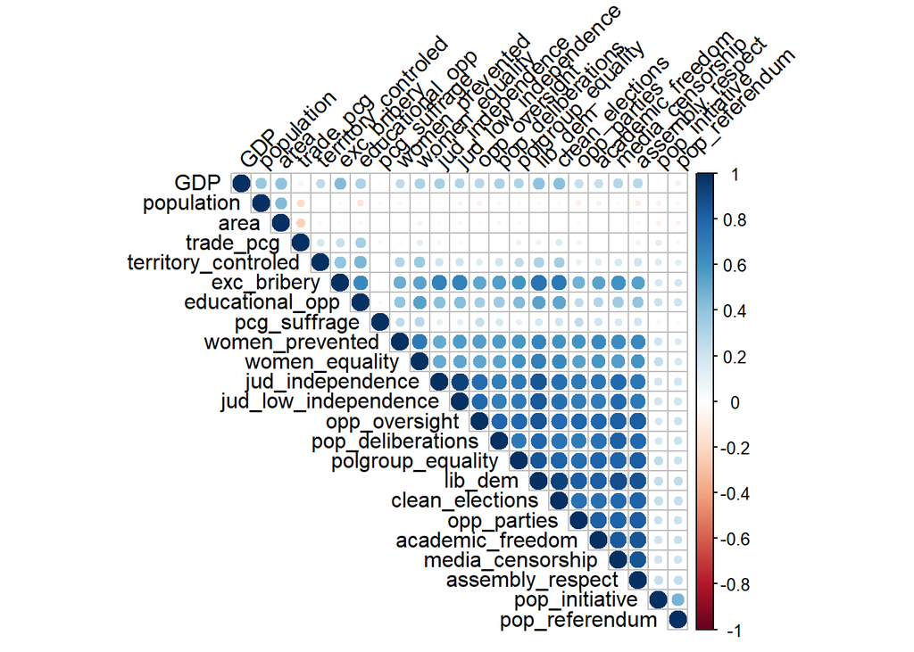

```r
data_corr <- df_final[5:28] %>% dplyr::select(-region)
corr_matrix <- cor(data_corr)
corrplot(corr_matrix, type = "upper", order = "hclust",
         tl.col = "black", tl.srt = 45)
```

The plot above shows the linear correlation between the variables. On the one hand we may see that most of the democratic features are highly related between them (the bigger the size of the circles, the biggest the correlation). On the other hand, trade seem to not be linearly related to any of them. Only a small correlation to educational opportunities and negative correlation with area.

#### Trade and liberal democracy

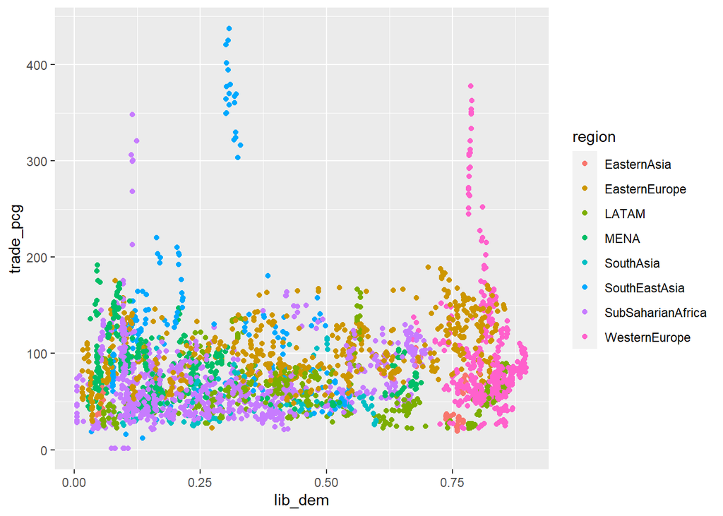

```r
p1 = ggplot(df_final)+
  geom_point(aes(lib_dem, trade_pcg, colour = region))
p1
```

Similarly, when plotting the relationship between liberal democracy and percentage of trade we cannot observe any linear pattern.

### Target variable description

Nonetheless, the most important descriptive part involves the target variable alone. We need to understand it for the future models to be applied.

#### Range

```r
summary(df_final$trade_pcg)
```

```
##    Min. 1st Qu.  Median    Mean 3rd Qu.    Max.
##   1.219  52.309  73.085  82.694 101.251 437.327
```

The first thing that stands out about the behaviour of the feature is the huge range. Taking into consideration its relative nature, the range is quite unusual: the maximum value is almost 450% of the GDP. In other words, the sum of import and exports of the country is four times bigger than the GDP. In the opposite side, there is a country that is completely closed to the interchange of goods: 1.2%.

#### Distribution

In order to visualize the distribution of the observations, we can plot and histogram by deciles.

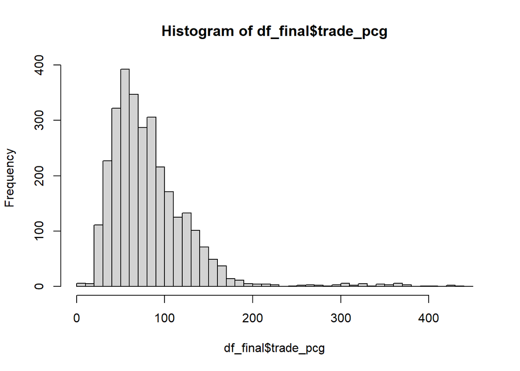

```r
seq <- seq(0, 450, by = 10)

hist(df_final$trade_pcg, breaks = seq)
```

However, as a first step in the analysis, we are interested in those countries with substantial low levels of trade; < 50%. More specifically, we will try to predict these countries them due to their democratic features. Then, we will try to predict the *exact* percentage according to these same variables.

## Feature Engineering

### 08’ crisis

For the moment, due to computational limitations we are only adding a new feature to the set of covariates. It constitutes a dummy variable accounting for 1 if the observation is pre-2008 crisis, and a zero if after it. This new feature will serve also to control for the dynamic nature of data. By adding this new factor we may observe the variability of the dependent variable due to this change in time.

```r
df_final <- df_final %>%
  mutate(
    precrisis = as.factor(case_when(
      year < 2008 ~ 0,
      year >= 2008 ~ 1)))
```

## Clasification: Interpretative tools

Before going into the models themselves, we need to define what a *low trader* country is. According to the histograms showed above, most of the countries are above the 50% point of trade relative to the GDP. Thus, we will consider that these countries that the volume of imports and exports do not sum up to half of the country’s GDP as *low traders*. Then, first, we will try to explain the belonging to that group based on democratic features. After that, using machine learning tools we will try to predict it.

Also, one of the main difficulties that we will face is the non-linearity of data between the features and the outcome; as the correlation matrix and plot showed, we can not summarize in an straight line the relationship between them. Thus, when constructing the models we would need to account for that.

### Categorical Y

To fulfil the objectives, it is necessary to define the new variable as a categorical one. Those countries with less than 50% of trade would be labelled as ‘1’ and the rest as ‘0’. As a descriptive note, we can observe that data is quite unbalanced as 22% are ‘1s’ and 78% are ‘0s’.

```r
df_categorical <- df_final %>%
  mutate (
  low_trader = as_factor(if_else(trade_pcg < 50, 1, 0))) %>%
  dplyr::select(-trade_pcg, -year, -country_name, -CountryCode, -lib_dem, -country_year)

prop.table(table(df_categorical$low_trader))
```

```
##
##         0         1
## 0.7758851 0.2241149
```

### Splitting dataset

Next (and final) task we should do before constructing the model is to split the dataset. As we want our models to be general, we will train them with a majority portion of the data, and then, we will test it with the rest.

```r
in_trainC <- createDataPartition(df_categorical$low_trader, p = 0.75, list = FALSE)
trainingC <- df_categorical[ in_trainC,]
testingC <- df_categorical[-in_trainC,]
```

### Logistic Regression

The first model that we will use to explain the relationship between democracy and trade is logistic regression. It is a generalized linear model, in the sense that instead of modelling the (linear) relationships between the dependent and the covariates, we would be modelling the linear relationship between the covariates and the log odds of Y = 1. Thus, we would be solving the non linearity of data with actual linear models; in theoretical terms, the relationship between the odds of Y = 1 and the covariates would indeed form a straight line.

```r
logistic = glm(low_trader ~., family = "binomial", data = trainingC)
summary(logistic)
```

```
##
## Call:
## glm(formula = low_trader ~ ., family = "binomial", data = trainingC)
##
## Deviance Residuals:
##      Min        1Q    Median        3Q       Max
## -2.16049  -0.62413  -0.26328  -0.05891   2.88990
##
## Coefficients:
##                           Estimate Std. Error z value Pr(>|z|)
## (Intercept)             -6.731e+01  5.873e+01  -1.146 0.251724
## clean_elections         -1.578e+00  4.704e-01  -3.356 0.000792 ***
## pcg_suffrage             6.035e-01  5.875e-01   1.027 0.304339
## opp_parties             -1.123e-01  9.334e-02  -1.203 0.229030
## pop_initiative          -1.263e+00  6.498e-01  -1.943 0.052001 .
## pop_referendum           1.484e+00  4.955e-01   2.995 0.002743 **
## exc_bribery              2.666e-01  8.021e-02   3.323 0.000889 ***
## opp_oversight            1.153e-01  9.253e-02   1.246 0.212603
## pop_deliberations        2.035e-01  1.150e-01   1.770 0.076660 .
## jud_independence         3.141e-01  1.142e-01   2.750 0.005953 **
## jud_low_independence    -2.608e-01  1.377e-01  -1.893 0.058297 .
## territory_controled     -2.769e-02  7.815e-03  -3.544 0.000394 ***
## women_prevented         -5.016e-01  1.247e-01  -4.023 5.75e-05 ***
## media_censorship         1.702e-01  1.116e-01   1.525 0.127151
## educational_opp         -1.761e-01  8.328e-02  -2.115 0.034455 *
## women_equality           4.127e-01  9.849e-02   4.190 2.79e-05 ***
## polgroup_equality       -6.986e-02  9.103e-02  -0.767 0.442829
## assembly_respect        -3.113e-01  1.024e-01  -3.041 0.002354 **
## academic_freedom        -2.007e-01  1.021e-01  -1.967 0.049198 *
## regionEasternEurope     -2.989e+00  6.213e-01  -4.811 1.50e-06 ***
## regionLATAM              5.528e-01  5.059e-01   1.093 0.274517
## regionMENA              -2.292e+00  5.191e-01  -4.415 1.01e-05 ***
## regionSouthAsia          1.928e+00  5.446e-01   3.540 0.000400 ***
## regionSouthEastAsia     -2.261e+00  5.640e-01  -4.009 6.09e-05 ***
## regionSubSaharianAfrica  3.401e-01  5.177e-01   0.657 0.511302
## regionWesternEurope     -2.434e+00  4.739e-01  -5.136 2.80e-07 ***
## population              -1.796e-09  6.172e-10  -2.910 0.003620 **
## area                     2.186e-07  3.409e-08   6.413 1.43e-10 ***
## GDP                      4.131e-01  5.720e-02   7.222 5.14e-13 ***
## precrisis1              -4.274e-01  1.352e-01  -3.161 0.001570 **
## ---
## Signif. codes:  0 '***' 0.001 '**' 0.01 '*' 0.05 '.' 0.1 ' ' 1
##
## (Dispersion parameter for binomial family taken to be 1)
##
##     Null deviance: 2392.1  on 2246  degrees of freedom
## Residual deviance: 1646.0  on 2217  degrees of freedom
## AIC: 1706
##
## Number of Fisher Scoring iterations: 12
```

The figures of the model show interesting results. On the hand, most of the variables seem to be statistically significant for at least the 95% confidence level. This would imply that we could be sure that the coefficients showed in the model are reliable. So at this point, we may assess that we could actually perform an analysis on trade based on democratic variables: 95 out of 100 times we can quantify their effect on trade. However, the significance level only allow us to check whether we can be sure that the estimation for the effect is correct, not the actual effect.

The first hint that would enable us to see if the model is appropriate to explain the variability in log odds of Y is the differences in deviances: The residual is lower than the null one. Therefore, we can assume that the errors in the predicted odds are lower when adding the covariates than using only the intercept. In other words, we may explain better the log odds of being *low trader* when using our explanatory variables. So, which is the individual effect of each covariate?. To calculate the actual increment in odds, we should take the exponential of each individual coefficient (we were calculating log odds, so we need to get rid of that ‘log’)

```r
exp(coef(logistic))
```

```
##             (Intercept)         clean_elections            pcg_suffrage
##            5.850579e-30            2.063038e-01            1.828461e+00
##             opp_parties          pop_initiative          pop_referendum
##            8.937957e-01            2.829222e-01            4.410775e+00
##             exc_bribery           opp_oversight       pop_deliberations
##            1.305472e+00            1.122244e+00            1.225730e+00
##        jud_independence    jud_low_independence     territory_controled
##            1.368986e+00            7.704612e-01            9.726855e-01
##         women_prevented        media_censorship         educational_opp
##            6.055417e-01            1.185522e+00            8.385223e-01
##          women_equality       polgroup_equality        assembly_respect
##            1.510826e+00            9.325277e-01            7.324718e-01
##        academic_freedom     regionEasternEurope             regionLATAM
##            8.181410e-01            5.032873e-02            1.738152e+00
##              regionMENA         regionSouthAsia     regionSouthEastAsia
##            1.010392e-01            6.873770e+00            1.042283e-01
## regionSubSaharianAfrica     regionWesternEurope              population
##            1.405027e+00            8.769369e-02            1.000000e+00
##                    area                     GDP              precrisis1
##            1.000000e+00            1.511430e+00            6.522272e-01
```

While being statistically significant, most of the variables do no have a substantial effect on the odds of Y = 1. Most of the coefficients show values around 1. As an example, an increase of 1 unit in executive bribery leads to and increase of 1.3 in the odds of a country for being a *low trader*. The sign of the coefficient is still mentionable. From a social sciences point of view, it is not fully interpretable: the less prone to corruption a government is, the less likely to engage in international trade. Investors should not as be suspicious of these kind of governments. Among the few variables that do have a substantial effect we we find South Asia region (as factor) and popular referendum. Both case could be considered as a surprise as the South Asia counts with one of the biggest countries in the worlds in terms of GDP: India. The odds of being a *low trader* country increases (by 6 times) despite belonging to such region. Similarly, the more possibility of a popular referendum, the more likely of Y = 1.

### Confusion matrix

While it is not the main objective at this stage, we may try to predict already in the testing set the countries that are *low traders*. On the one hand, it would serve as a reference model for the future. Logistic models is the “simplest” one, so whenever we increase the complexity in the models, we may compare their performances.

In this line of reasoning, we would need to set a threshold for which we would consider a country a *low trader*. Putting it simply, if the model predict a particular observation to have 0.25 of probabilities to be 1, we would already set it as *low trader*. By setting this low threshold, we aim to correct the imbalances of the observations described above.

```r
probabilities_log <- predict(logistic, newdata=testingC, type='response')
prediction_log <- as.factor(ifelse(probabilities_log > 0.25, "1", "0"))
```

```r
confusionMatrix(prediction_log, testingC$low_trader)$table
```

```
##           Reference
## Prediction   0   1
##          0 437  33
##          1 143 134
```

```r
confusionMatrix(prediction_log, testingC$low_trader)$overall[1:2]
```

```
##  Accuracy     Kappa
## 0.7643909 0.4502530
```

The main tool that serve to evaluate the predictive power of the model is the confusion matrix. It accounts for the number of observations that it correctly predicted, either ‘0s’ and ‘1s’, and the number of observations that it missed. As we are interested in predicting countries with low levels of trade, we should focus on the ‘1s’.

On the one hand, due to the low threshold, we have a significant amount of false positives, as we labelled them as ‘1s’ when in reality they were ‘0s’. These mistakes are of low importance. On the other hand, we had a handful of costly mistakes, in the sense that we were unable to forecast them as low traders: false negatives. If we were policy makers or investors, we could be losing very important observations. As these are precisely the objective, we would need to minimize this number. Finally, we had an accuracy of 76%, meaning that we predicted correctly 76% of the observations.

## Clasification: prediction tools.

In order to improve these predictions we are going to resort to machine learning tools. More specifically, they are supervised tools, as they need to be trained with certain parameters specified by us. Also, with the inputs provided, these algorithms will try to predict and output Y, in our case *low trader*.

### LDA

#### The model

The first predictive tools is Linear Discriminant Analysis. Assuming Bayesian probabilities, it will try to classify each observation into the two different groups. While in theory it is used an interpretative tool rather than predictive, we may run the analysis just to check if the performance is better than the logistic. It usually expects to find more than two groups, so the figures would not be as important.

```r
lda <- lda(low_trader ~ ., data=trainingC)
lda
```

```
## Call:
## lda(low_trader ~ ., data = trainingC)
##
## Prior probabilities of groups:
##         0         1
## 0.7757009 0.2242991
##
## Group means:
##   clean_elections pcg_suffrage opp_parties pop_initiative pop_referendum
## 0       0.5746799     97.68373   1.2107510     0.08909925     0.05162364
## 1       0.4656726     99.99603   0.9930258     0.02805556     0.03408730
##   exc_bribery opp_oversight pop_deliberations jud_independence
## 0   0.1175404     0.8137631         1.0412266        0.4728921
## 1  -0.2637242     0.5735119         0.9309563        0.2517302
##   jud_low_independence territory_controled women_prevented media_censorship
## 0            0.5949667            92.84201        1.422569        0.8306443
## 1            0.2799663            89.43305        1.155391        0.6173274
##   educational_opp women_equality polgroup_equality assembly_respect
## 0      0.86864257       1.529009         1.1481572        1.0792834
## 1     -0.07213492       1.248744         0.6743413        0.5806746
##   academic_freedom regionEasternEurope regionLATAM regionMENA regionSouthAsia
## 0        0.9432760          0.24383247  0.09982788 0.13138267      0.01549053
## 1        0.6485794          0.02777778  0.21230159 0.07142857      0.12896825
##   regionSouthEastAsia regionSubSaharianAfrica regionWesternEurope population
## 0          0.07401033               0.2438325          0.17900172   24246851
## 1          0.02182540               0.4067460          0.08333333  108090845
##        area      GDP precrisis1
## 0  554033.1 24.47737  0.6161790
## 1 1768067.8 24.95179  0.5972222
##
## Coefficients of linear discriminants:
##                                   LD1
## clean_elections         -1.203729e+00
## pcg_suffrage             1.830440e-02
## opp_parties             -6.086614e-02
## pop_initiative          -3.071852e-01
## pop_referendum           5.840638e-01
## exc_bribery              1.863791e-01
## opp_oversight            7.512898e-02
## pop_deliberations        6.604618e-02
## jud_independence         2.904907e-01
## jud_low_independence    -1.994670e-01
## territory_controled     -1.883892e-02
## women_prevented         -3.414312e-01
## media_censorship         1.041012e-01
## educational_opp         -1.040928e-01
## women_equality           2.392628e-01
## polgroup_equality       -5.482079e-02
## assembly_respect        -1.457153e-01
## academic_freedom        -1.092362e-01
## regionEasternEurope     -1.191977e+00
## regionLATAM              3.101309e-01
## regionMENA              -1.602513e+00
## regionSouthAsia          1.652518e+00
## regionSouthEastAsia     -1.691470e+00
## regionSubSaharianAfrica  1.568163e-01
## regionWesternEurope     -1.685111e+00
## population              -5.639378e-10
## area                     1.706298e-07
## GDP                      2.696672e-01
## precrisis1              -2.736977e-01
```

Even if not interested in the coefficients, we can see that the region is again one of the variables with one of the most substantial importance to classify observations.

#### Confusion matrix

```r
probability_lda <- predict(lda, newdata=testingC)$posterior
prediction_lda <- as.factor(ifelse(probability_lda[,2] > 0.25, '1', '0'))
```

```r
confusionMatrix(prediction_lda, testingC$low_trader)$table
```

```
##           Reference
## Prediction   0   1
##          0 458  46
##          1 122 121
```

```r
confusionMatrix(prediction_lda, testingC$low_trader)$overall[1:2]
```

```
##  Accuracy     Kappa
## 0.7751004 0.4425076
```

After performing the predictions in the testing dataset, we may observe the accuracy and the number of false positives is more or less the same as the logistic regression. It makes sense as the logic behind the model is very similar. Both methods try to model a linear relationship between the covariates and probabilities/odds. Thus, we could expect such similar performances.

#### ROC Curve

```r
roc.lda <- roc(testingC$low_trader ~ probability_lda[,2])
```

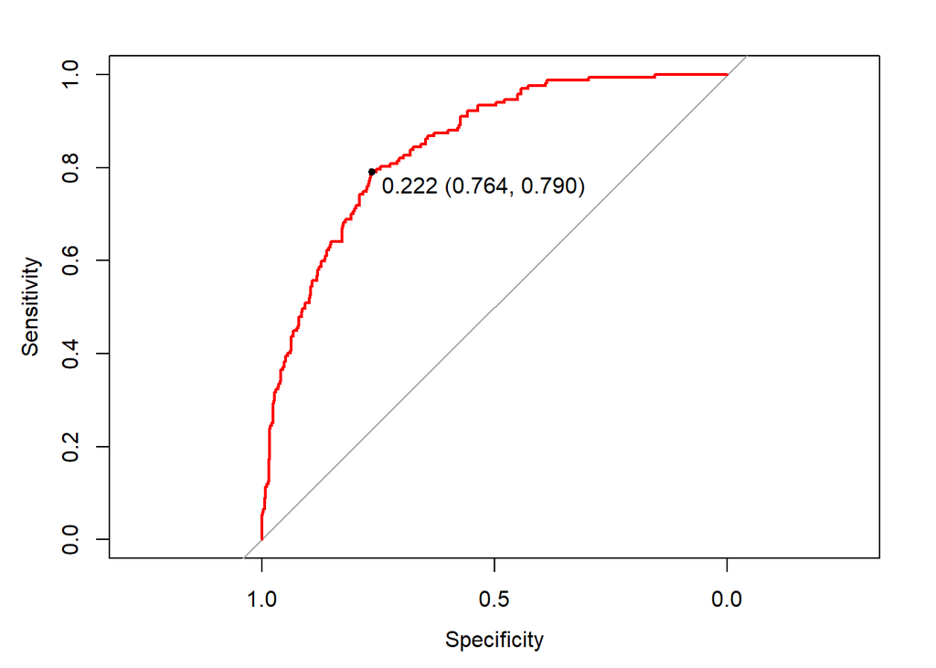

```r
plot(roc.lda, col="red",print.thres=TRUE)
```

### Train control for Machine Learning

To maximize predictions, we are going to include cross validation. This technique would allow us to train the model various times using k-folds; we will divide the training dataset in 7 separate parts, and will train a different model with a combination of 6 part and validate them in the fold not included. This would show the most optimal combination of coefficients to predict.

```r
ctrl_c <- trainControl(method = "repeatedcv",
                     number = 7,
                     classProbs = T,
                     summaryFunction=twoClassSummary,
                     verboseIter = T)
```

### Renaming levels

For the algorithms to properly work, we would need to rename the output variable into “No” and “Yes”.

```r
levels(trainingC$low_trader)=c("No","Yes")
levels(testingC$low_trader)=c("No","Yes")
```

### K-nearest-neighbours (KNN)

The first tools that we will use is the K-nearest neighbours. For each particular observation, it will look to the ‘10’ closest ones for classifying. The more a abundance from a particular group (‘no’s and ’yes’) the neighbours, the more probable to assign such group to the observation analysed. While it is not the most optimal algorithm, due to the geographical nature of the data makes sense to include this kind of tool. Metaphorical neighbours could be actual neighbours in spatial and time terms.

#### The model

```r
knn_model <- train(low_trader ~ .,
                data = trainingC,
                method = "kknn",
                preProc=c('scale','center'),
                tuneLength = 10,
                metric="ROC",
                trControl = ctrl_c)
```

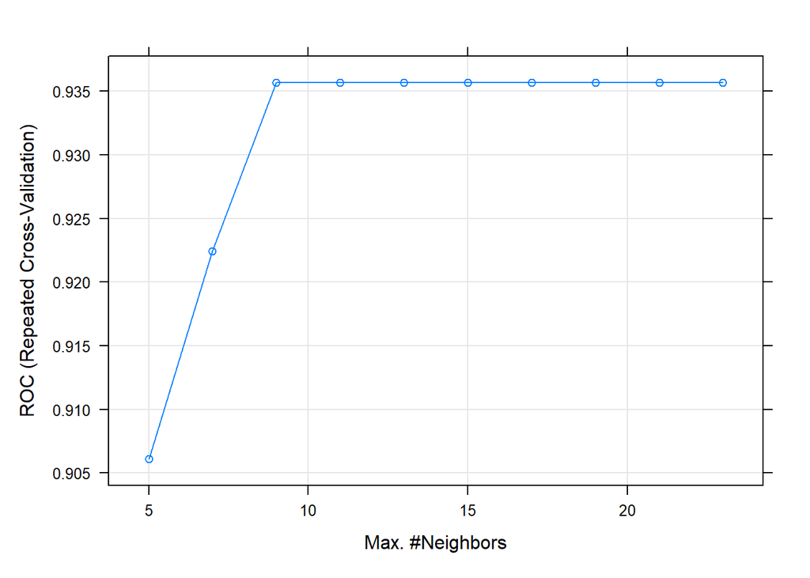

```r
plot(knn_model)
```

#### Predictions

```r
probabilities_knn = predict(knn_model, testingC, type="prob")
prediction_knn <- as.factor(ifelse(probabilities_knn[,2] > 0.25, "Yes", "No"))

confusionMatrix(prediction_knn, testingC$low_trader)$table
```

```
##           Reference
## Prediction  No Yes
##        No  537  10
##        Yes  43 157
```

```r
confusionMatrix(prediction_knn, testingC$low_trader)$overall[1:2]
```

```
##  Accuracy     Kappa
## 0.9290495 0.8090611
```

### Random Forest

The next model we will use to classify countries is Random Forest. This technique is quite different to KNN. For each observation, we will select a particular variable with an established threshold. If the observation falls below that point it would be classified as ‘0’; if above that point, ‘1’. This process, however, is going to be successively repeated with many variables to avoid mistakes (decision tree). Then, this very same model will be repeated up to 10 times, to reduce bias. Apart from the iterations, each time the algorithm is going to select by chance a random number of predictors, in order to minimize the variance. Finally, we will include also cross validation to optimize the performance of the ROC curve. Therefore, as there would be many iterations for the decisions trees, the performance of the model is ultimately maximized.

#### The model

```r
rf_model <- train(low_trader ~ .,
               data = trainingC,
               method = "rf",
               preProc=c('scale','center'),
               tuneLength = 10,
               metric="ROC",
               trControl = ctrl_c)
```

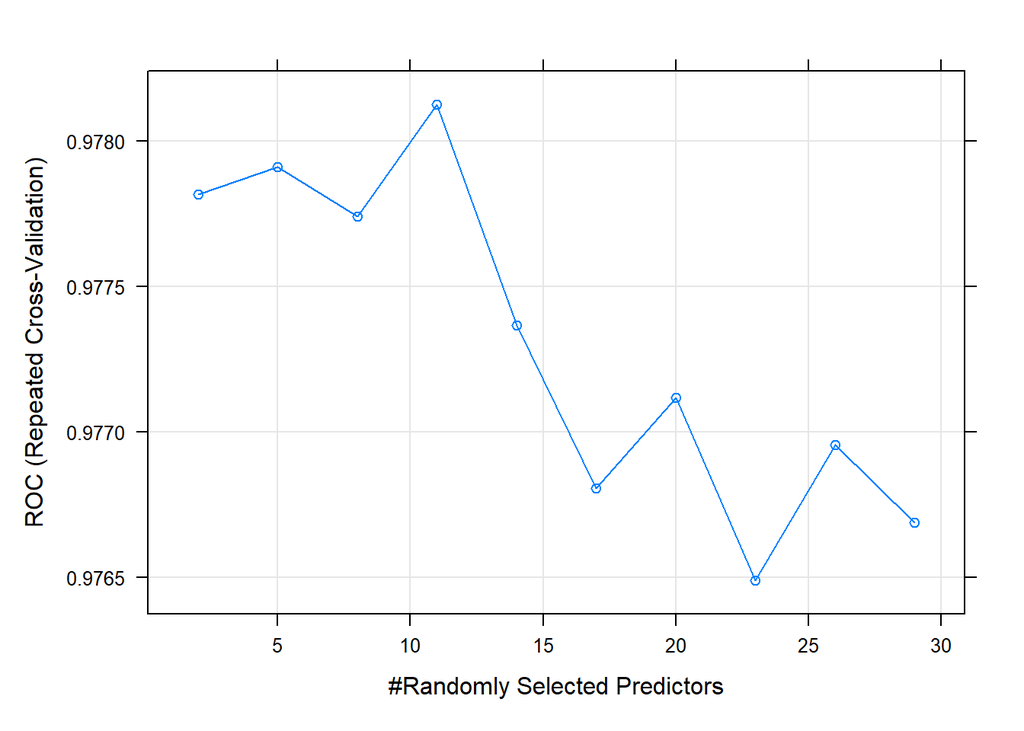

```r
plot(rf_model)
```

Attending to the plot above, the ROC seem to be maximized with around 5-10 random predictors. Interestingly, the more covariates the less area under the curve. It would seem that we would be introducing bias into the model without improving accuracy. In any case, the performance metric show and interval between 0.9765 and almost 0.98, which in the end is a *fantastic* result.

#### Predictions

```r
probabilities_rf = predict(rf_model, testingC, type="prob")
prediction_rf <- as.factor(ifelse(probabilities_rf[,2] > 0.25, "Yes", "No"))

confusionMatrix(prediction_rf, testingC$low_trader)$table
```

```
##           Reference
## Prediction  No Yes
##        No  545  12
##        Yes  35 155
```

```r
confusionMatrix(prediction_rf, testingC$low_trader)$overall[1:2]
```

```
##  Accuracy     Kappa
## 0.9370817 0.8272356
```

### Variable importance

While the functioning of these algorithms is a black box, in the sense that we cannot know what is happening, we can indeed guess which are the most important variables for each of the algorithms to classify observations.

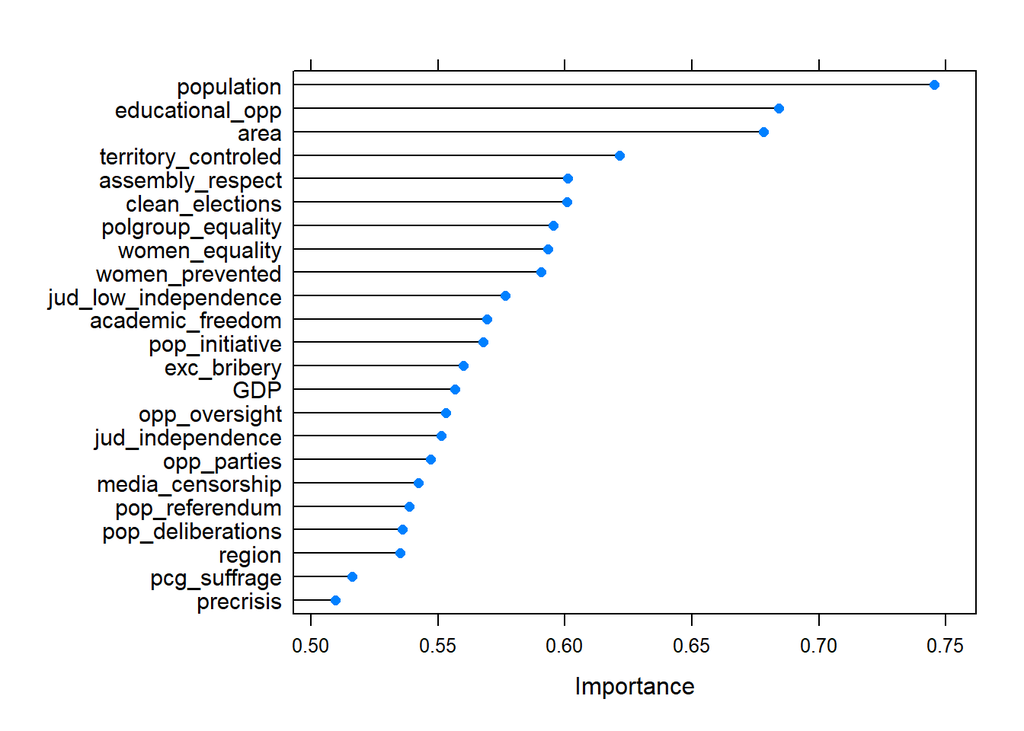

```r
knn_imp <- varImp(knn_model, scale = F)
plot(knn_imp, scales = list(y = list(cex = .95)))
```

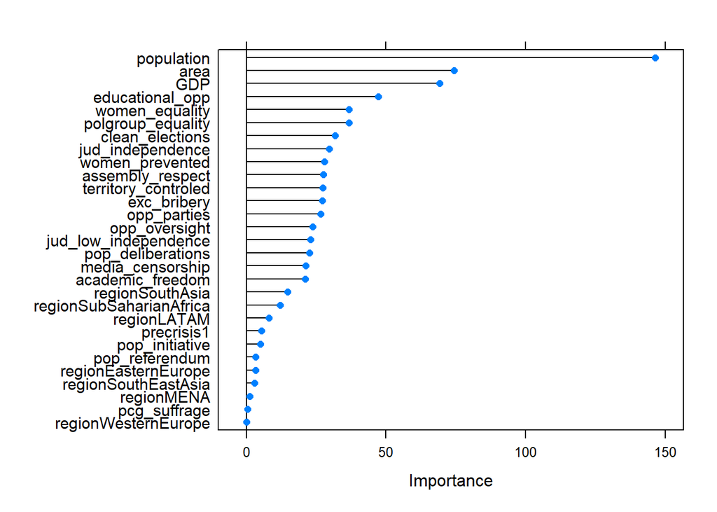

```r
rf_imp <- varImp(rf_model, scale = F)
plot(rf_imp, scales = list(y = list(cex = .95)))
```

In both cases, population and area are the most important variables to predict *low traders*. It makes sense that small countries would need to import and export goods. However, with respect to KNN, educational opportunities seem to be as important. After these three variables, the importance of the variables decreases steadily, being territory controlled and the presence of clean elections also important. The presence of these two variables also makes sense, as from investor’s point of view, the presence of strong state in all the territory and democratic rule could assure the investment is reliable.

With respect to random forest, we can see the steady decrease in importance for most the variables as well, being educational opportunities and women equality somehow important. Nonetheless, what is more interesting in this algorithm is the none importance of the region variable to predict *low traders*. For this particular algorithm, the geo-political position of an observation does not help to predict its openness.

## Advance regression: interpretation tools

The second analysis of this report would be to predict the exact % of trade for each observation considering the democratic features.

### Splitting dataset and train control

For this kind of analysis, we will also need to split the dataset for training and testing, as well as selecting only the numeric and factor variables. This time however the cross validation is going to be simplier, as we don’t need to include probabilities, just the number of folds. Due to computational resources, this time we will divide the training dataset in 5 folds and repeat the process only 1 time.

```r
df_numeric <- df_final[6:29]

in_trainR <- createDataPartition(df_numeric$trade_pcg, p = 0.75, list = FALSE)
trainingR <- df_numeric[ in_trainR,]
testingR <- df_numeric[-in_trainR,]

ctrl_R <- trainControl(method = "repeatedcv",
                     number = 5, repeats = 1)

linear_cv <- trade_pcg ~.
```

### Linear Regression

In order to construct a benchmark model, we will train a linear model. Knowing that at first sight there are no linear relationships between covariates and output, it is always a good idea to have a model which acts a reference one to compare with.

#### The model

```r
linear_model <- train(linear_cv, data = trainingR,
                 method = "lm",
                 preProc=c('scale', 'center'),
                 trControl = ctrl_R)
linear_model
```

```
## Linear Regression
##
## 2246 samples
##   23 predictor
##
## Pre-processing: scaled (29), centered (29)
## Resampling: Cross-Validated (5 fold, repeated 1 times)
## Summary of sample sizes: 1798, 1796, 1797, 1796, 1797
## Resampling results:
##
##   RMSE      Rsquared   MAE
##   38.15593  0.3672893  26.8498
##
## Tuning parameter 'intercept' was held constant at a value of TRUE
```

```r
summary(linear_model)
```

```
##
## Call:
## lm(formula = .outcome ~ ., data = dat)
##
## Residuals:
##      Min       1Q   Median       3Q      Max
## -113.813  -23.051   -2.627   16.785  267.120
##
## Coefficients:
##                         Estimate Std. Error t value Pr(>|t|)
## (Intercept)              82.9018     0.8018 103.397  < 2e-16 ***
## clean_elections           8.6369     2.0154   4.285 1.90e-05 ***
## pcg_suffrage             -1.5442     0.9331  -1.655 0.098096 .
## opp_parties              14.9579     1.7733   8.435  < 2e-16 ***
## pop_initiative            1.0816     0.9862   1.097 0.272887
## pop_referendum           -1.4342     0.9304  -1.542 0.123318
## exc_bribery              11.6353     1.6474   7.063 2.18e-12 ***
## opp_oversight           -10.3487     1.9207  -5.388 7.87e-08 ***
## pop_deliberations        -9.7623     1.6305  -5.987 2.48e-09 ***
## jud_independence         -2.9446     2.3938  -1.230 0.218792
## jud_low_independence    -11.8346     2.4506  -4.829 1.46e-06 ***
## territory_controled       1.6228     0.9921   1.636 0.102032
## women_prevented          -5.2885     1.3858  -3.816 0.000139 ***
## media_censorship          4.8832     2.2177   2.202 0.027771 *
## educational_opp          12.9427     1.5526   8.336  < 2e-16 ***
## women_equality           -2.6570     1.4253  -1.864 0.062441 .
## polgroup_equality         2.7155     1.8240   1.489 0.136706
## assembly_respect          3.0054     2.2033   1.364 0.172693
## academic_freedom          2.0884     1.8954   1.102 0.270645
## regionEasternEurope      14.3630     2.9099   4.936 8.57e-07 ***
## regionLATAM               3.8812     2.6007   1.492 0.135752
## regionMENA               11.9508     2.4312   4.916 9.50e-07 ***
## regionSouthAsia           1.4007     1.5571   0.900 0.368483
## regionSouthEastAsia      20.2201     1.8457  10.955  < 2e-16 ***
## regionSubSaharianAfrica   9.4369     3.4102   2.767 0.005699 **
## regionWesternEurope       9.9598     2.5784   3.863 0.000115 ***
## population                2.4019     1.1509   2.087 0.037000 *
## area                     -6.0732     1.0038  -6.050 1.69e-09 ***
## GDP                     -10.3863     1.3801  -7.526 7.58e-14 ***
## precrisis1                3.7619     0.8471   4.441 9.41e-06 ***
## ---
## Signif. codes:  0 '***' 0.001 '**' 0.01 '*' 0.05 '.' 0.1 ' ' 1
##
## Residual standard error: 38 on 2216 degrees of freedom
## Multiple R-squared:  0.3811, Adjusted R-squared:  0.373
## F-statistic: 47.05 on 29 and 2216 DF,  p-value: < 2.2e-16
```

#### Prediction

In order to analyse the different performances of the models, we are going to create a data frame in which we would be *adding* the original value in testing set and the predicted of each model. Even if linear model is not the best performer, we are going to include its predictions to establish a benchmark model towards we may compare the rest.

```r
test_results <- data.frame(trade_pcg = testingR$trade_pcg)
test_results$lm <- predict(linear_model, testingR)
postResample(pred = test_results$lm,  obs = test_results$trade_pcg)
```

```
##       RMSE   Rsquared        MAE
## 36.8882124  0.3876599 25.8991669
```

### Step Wise

In terms of interpretation models, we may resort to the stepwise model to discover which are the variables that would serve to explain variability in the output. In theoretical terms, stepwise would start by taking all the possible correlations of covariates that explain Y, and at the same time it will start with the pair of covariates with the highest correlation. At each iteration, the algorithm will remove one variable from the first group, and add another one to the second one. This have to objective to optimize the number of variables, and retaining the minimum covariates with significance that explain the most possible variability of Y. In the end, we would try to reduce the variance by finding the most relevant variables, and thus introducing also some bias into the model. To maximize performance, it also includes cross validation.

#### The model

```r
step_model <- train(linear_cv, data = trainingR,
                   method = "leapSeq",
                   preProc=c('scale', 'center'),
                   tuneGrid = expand.grid(nvmax = 4:10),
                   trControl = ctrl_R)

coef(step_model$finalModel, step_model$bestTune$nvmax)
```

```
##         (Intercept)     clean_elections         opp_parties       opp_oversight
##           82.901773           10.290545           14.821657          -19.910623
##     educational_opp          regionMENA regionSouthEastAsia                 GDP
##           19.587085            6.864899           14.254024          -13.111897
```

#### Prediction

```r
test_results$step <- predict(step_model, testingR)
postResample(pred = test_results$step,  obs = test_results$trade_pcg)
```

```
##       RMSE   Rsquared        MAE
## 38.5667085  0.3313687 26.4727660
```

### Lasso

The final interpretative tool that we will use to explain the variability in the output is the Lasso Regression. It is a regularized linear model. The idea would be to minimize the error formula that is used to find the best model (L2 regularization) by adding a parameter. The error term equation would be calculated with different lamba hyperparameters in order to find the most optimal combination that even if adding some bias, the variance is reduced, so the performances would be better.

#### Model and Control

```r
ModelL <- trade_pcg ~ opp_parties + exc_bribery + opp_oversight + jud_independence + women_prevented +  educational_opp + region + population + area

lasso_grid <- expand.grid(fraction = seq(.01, 1, length = 100))
```

#### The model

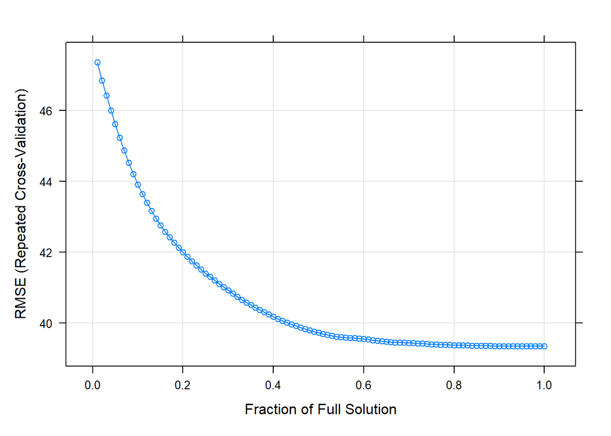

```r
lasso_model <- train(ModelL, data = trainingR,
                    method='lasso',
                    preProc=c('scale','center'),
                    tuneGrid = lasso_grid,
                    trControl=ctrl_R)
plot(lasso_model)
```

```r
lasso_model$bestTune
```

```
##    fraction
## 98     0.98
```

#### Prediction

```r
test_results$lasso<- predict(lasso_model, testingR)
postResample(pred = test_results$lasso,  obs = test_results$trade_pcg)
```

```
##       RMSE   Rsquared        MAE
## 36.4963075  0.4006606 26.3522771
```

## Advance regression: prediction tools

Even if the amount of variability we can explain is limited, we may still be able to predict with great amount of accuracy the exact level of trade using other machine learning tools. Taking advantage of the trade-off between bias and variance, the machine learning tools used before would serve us again to predict this number. Then, even if interpretability is reduced due to the huge amount of noise that we would include, there would be some conclusions that we could draw.

### The model

The first task we may do is to redefine the model by adding once again all the original variables.

```r
ModelP <- trade_pcg ~.
```

### Elastic Net

Elastic net model is the combination of Ridge Regression (not used before) and Lasso. It is a regularized linear model that add hyperparameters into the error formula (as lasso) and in the cross validation process (as Ridge regression). The theoretical idea of Elastic Net models is to obtain gather the best features of both types of model: The combination of the optimization of each of the terms would improve the predictive power of the model.

#### Model

Thus, we would need to define a new grid for this specific model, considering the two hyperparameters.

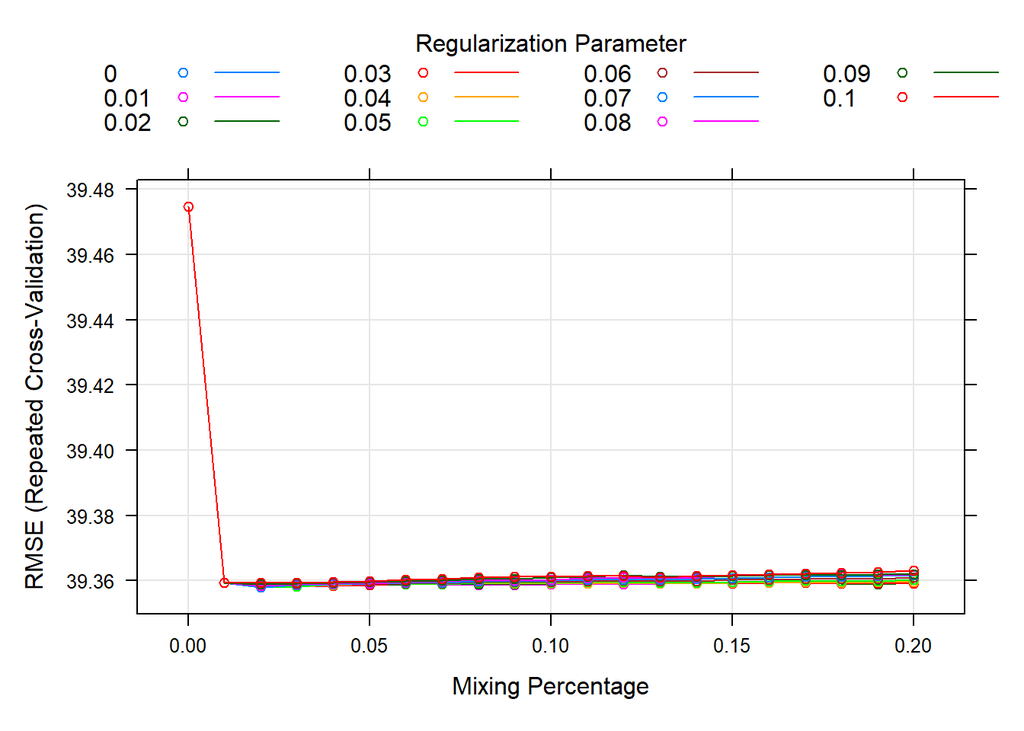

```r
elastic_grid = expand.grid(alpha = seq(0, .2, 0.01), lambda = seq(0, .1, 0.01))

elastic_model <- train(ModelL, data = trainingR,
                     method='glmnet',
                     preProc=c('scale','center'),
                     tuneGrid = elastic_grid,
                     trControl=ctrl_R)

plot(elastic_model)
```

```r
elastic_model$bestTune
```

```
##    alpha lambda
## 30  0.02   0.07
```

#### Predictions

```r
test_results$elastic <- predict(elastic_model, testingR)
postResample(pred = test_results$elastic,  obs = test_results$trade_pcg)
```

```
##       RMSE   Rsquared        MAE
## 36.5037637  0.4004365 26.3255644
```

The performance metrics shows that even with the optimization of all possible terms is not enough. We reach the same trees hold as before.

### KNN

The next tool that we will use for predicting the exact bulk of trade in a country is K-Nearest Neighbourhoods. The idea is the similar as before: we will look into the most closest observations to predict the exact value of trade. However, during the cross validation process, it will use a different number of close neighbours each time (11, 13, 15, 19, 21), using a particular way to measure the distances; Minkowski.

#### The model

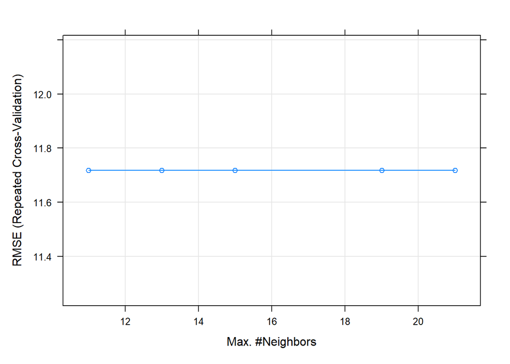

```r
knn_regression <- train(ModelP,
                  data = trainingR,
                  method = "kknn",
                  preProc=c('scale','center'),
                  tuneGrid = data.frame(kmax=c(11,13,15,19,21),distance=2,kernel='optimal'),
                  trControl = ctrl_R)
plot(knn_regression)
```

Once again, this algorithm proves once again a great amount of accuracy. The root mean square errors is reduced to 11!. It constitutes a substantial reduction from the other statistical learning models. The plot also shows that the number of neighbours does not affect the errors accumulated in the predictions.

#### Prediction

```r
test_results$knn <- predict(knn_regression, testingR)

postResample(pred = test_results$knn,  obs = test_results$trade_pcg)
```

```
##       RMSE   Rsquared        MAE
## 10.1014558  0.9541896  6.5286284
```

### Random Forest

The ‘last’ model we are going to use to predict is Random Forest. It follows the same logic as before. However, this time, we will specify the number of random predictors selected at each iteration (8, 12, 15, 20).

#### The model

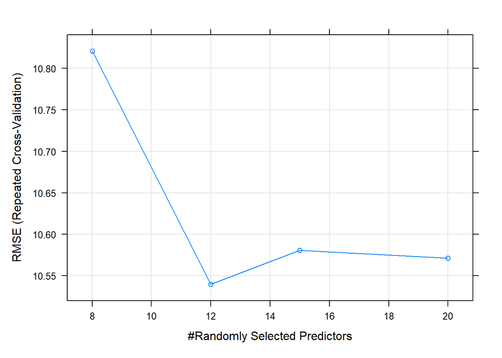

```r
rf_regression <- train(ModelP,
                 data = trainingR,
                 method = "rf",
                 preProc=c('scale','center'),
                 trControl = ctrl_R,
                 ntree = 100,
                 tuneGrid = data.frame(mtry=c(8,12,15,20)),
                 importance = TRUE)

plot(rf_regression)
```

#### Predictions

```r
test_results$rf <- predict(rf_regression, testingR)
postResample(pred = test_results$rf,  obs = test_results$trade_pcg)
```

```
##       RMSE   Rsquared        MAE
## 10.4739794  0.9509876  6.8023072
```

Random forest seem to be a similar predictor as the KNN as the mean average error stand also around 6%.

### Variable importances

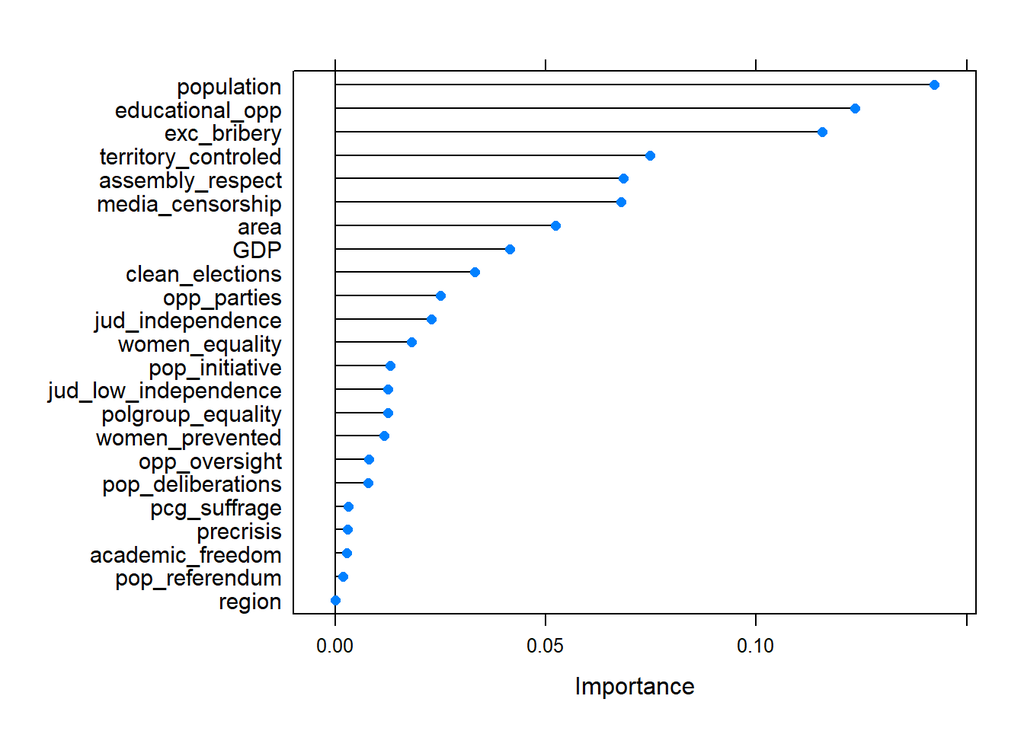

```r
plot(varImp(knn_regression, scale = F), scales = list(y = list(cex = .95)))
```

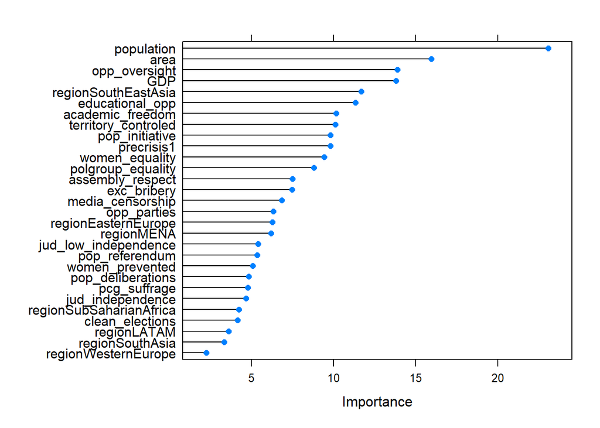

```r
plot(varImp(rf_regression, scale = F), scales = list(y = list(cex = .95)))
```

### Comparing predictions

In order to actually compare performance metrics, we may construct confidence interval for the predictions and calculate by hand the mean average error with the data frame that accounted with all the predictions.

```r
apply(test_results[-1], 2, function(x) mean(abs(x - test_results$trade_pcg)))
```

```
##        lm      step     lasso   elastic       knn        rf
## 25.899167 26.472766 26.352277 26.325564  6.528628  6.802307
```

Thus, using the apply function we can calculate *by hand* the mean average error of each model to see which are the more efficient. As it was already stated, both KNN and RF are the better performances. This information is important as we are to weight both of them to calculate confidence intervals for the predictions. In other words, we would be creating artificially the range of values in which the a predicted observation could be situated. To do that, we first need to obtain the mean of both mean errors and compare the average of predictions to the actual values to observe which would be the performance:

```r
test_results$comb <- (test_results$rf + test_results$knn)/2
postResample(pred <- test_results$comb,  obs = test_results$trade_pcg)
```

```
##      RMSE  Rsquared       MAE
## 9.7408698 0.9573885 6.3624680
```

The figures show that when combining both methods, the predictions are indeed more precise.

```r
yhat <- test_results$comb
head(yhat)
```

```
## [1] 54.73291 61.63085 66.84394 71.72023 79.71223 78.85403
```

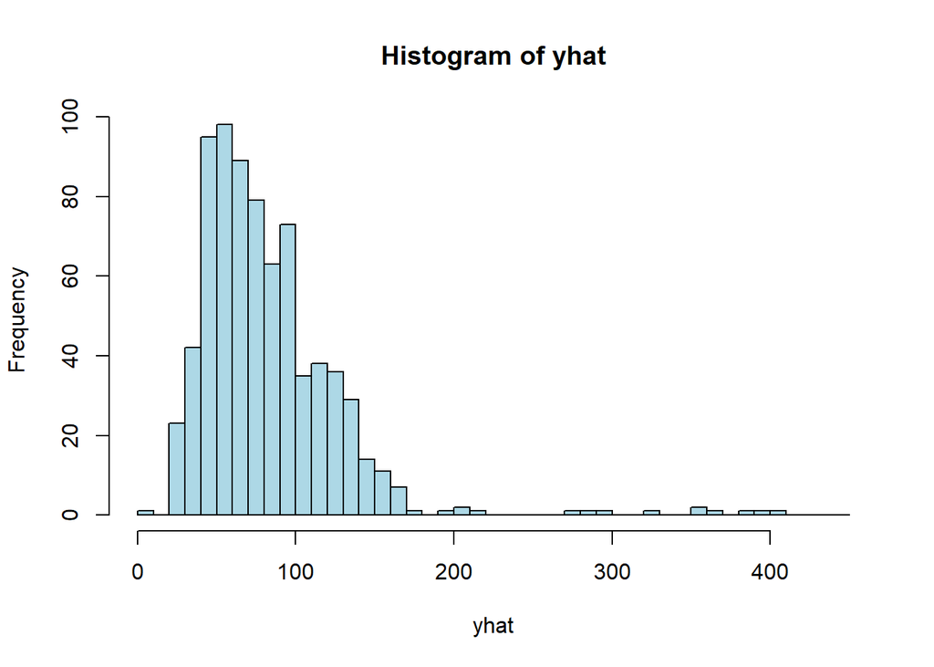

```r
hist(yhat, col="lightblue", breaks = seq)
```

In the plot above we can see that the distribution of the predicted value is very similar to the original variable, which is another sign of the good performance of the combination of the two models weighted

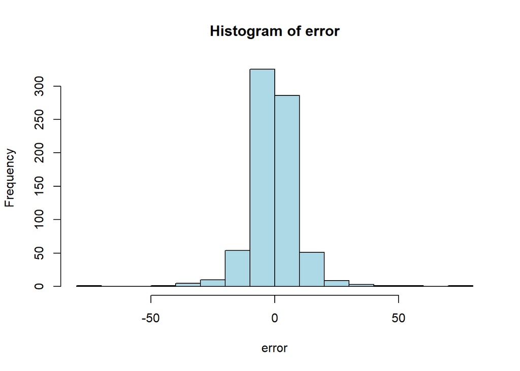

```r
y <- test_results$trade_pcg
error <- y-yhat
hist(error, col="lightblue")
```

Even the errors seems to follow a normal distribution, with the average around 0, as the plot above demonstrates.

```r
noise <- error[1:300]

lwr <- yhat[301:length(yhat)] + quantile(noise,0.05, na.rm=T)
upr <- yhat[301:length(yhat)] + quantile(noise,0.95, na.rm=T)

predictions <- data.frame(real=y[301:length(y)], fit=yhat[301:length(yhat)], lwr=lwr, upr=upr)

predictions <- predictions %>% mutate(out=factor(if_else(real<lwr | real>upr,1,0)))
```

Then, once the limits are set, we may visualize the results:

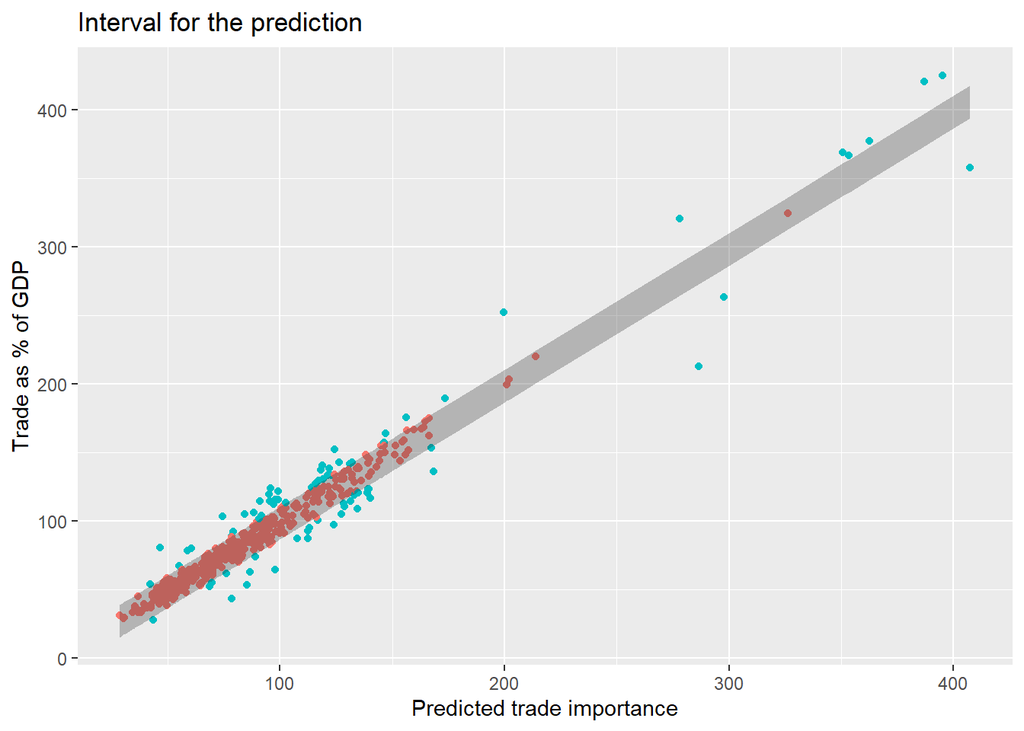

```r
ggplot(predictions, aes(x=fit, y=real))+
  geom_point(aes(color=out)) + theme(legend.position="none") +
  geom_ribbon(data=predictions,aes(ymin=lwr,ymax=upr),alpha=0.3) +
  labs(title = "Interval for the prediction", x = "Predicted trade importance",y="Trade as % of GDP")
```

The grey part correspond to the actual range of values in which we can assume the model predicted correctly. Red dots are the ones that fall under these range and blue ones are dots the models predicted wrongly. Up to 200% of trade relative to GDP, the model predict very good, as the number of blue dots is assumable as error. However, from this point onwards, the models are not able to predict correctly. At this specific case, we may assume that these observations are too special and outliers that even with sophisticated algorithms is not possible to predict them. Under these circumstances, we may focus only in the first range:

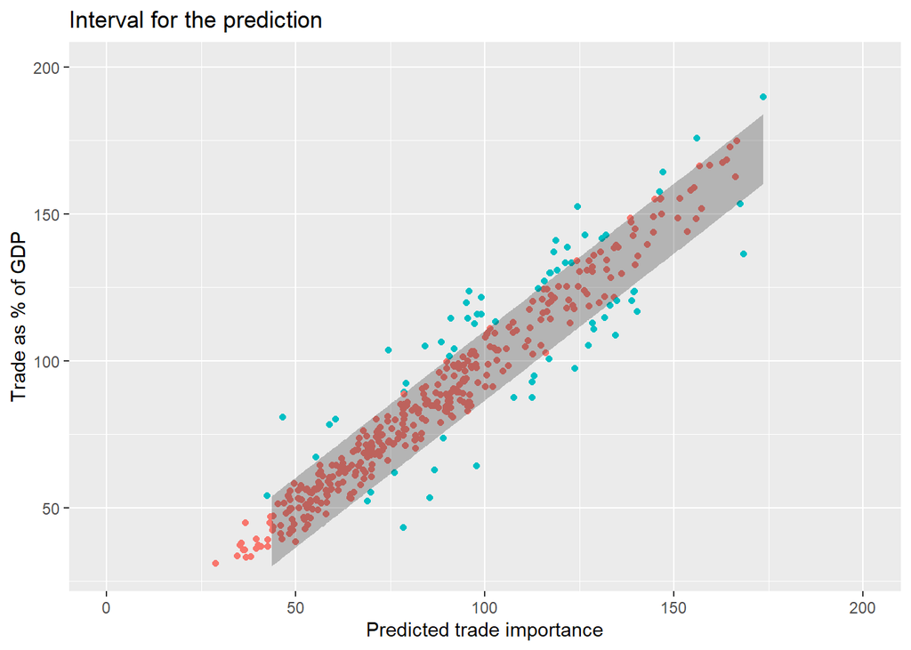

```r
ggplot(predictions, aes(x=fit, y=real))+
  geom_point(aes(color=out)) + theme(legend.position="none") +
  xlim(0, 200) + ylim(30, 200)+
  geom_ribbon(data=predictions,aes(ymin=lwr,ymax=upr),alpha=0.3)+
  labs(title = "Interval for the prediction", x = "Predicted trade importance",y="Trade as % of GDP")
```

A closer look into these set of points help to visualize that even those wrongly predicted are very close to the range of the confidence interval. Apart from that, we may conclude that those countries that are below the range of values could be trading below an optimal range, according to democratic features. In other words, foreign investors or trade organzations could go into these countries to promote a bit more their international business; according to their democratic features, there would be room for increasing the bulk of trade, respective to the GDP.

On the contrary, there are other countries that seem to depend too much on international exchanges, those above the confidence interval. These countries would be possessing much more trade than expected. In this scenario, they should cautions as it could be relying excessively on foreign interchanges, in respect to the democratic variables.